# Modelo regresión simple y multiple

Miguel Ángel Acosta Chinchilla

16/11/2021

$$CARGAMOS~LA~BASE~DE~DATOS$$
La base la llamamos *d*

```r
library(readxl)
library(ggplot2)
library(gridExtra)
d<-read_excel("C:\\Users\\MiguelAngel\\Documents\\R Miguelo\\Juan Ortiz (SanTT)\\Competitividad.xlsx")
```

#Variables evaluadas Global: Escalafón Global de Competitividad F.E.: Fortaleza de la Economía I.L.: Infraestructura y logística B.S.C.H.: Bienestar Social y Capital Humano C.T.I.: Ciencia, Tecnología e Innovación I.G.P.: Institucionalidad y Gestión Pública Regíon: Regón natural de Colombia

```r
head(d)
```

```
## # A tibble: 6 x 8
##   Dpto                  Global  F.E.  I.L. B.S.C.H. C.T.I. I.G.P. Región
##   <chr>                  <dbl> <dbl> <dbl>    <dbl>  <dbl>  <dbl> <chr>
## 1 Amazonas                28.7  30.3  21.3     20     26.4   50.5 Amazonía
## 2 Antioquia               71.1  75    66       76.6   60.2   79.3 Andina
## 3 Arauca                  35.7  35.4  36.3     45.5    4.9   61.5 Orinoquía
## 4 Atlántico               67.1  71.7  74.6     77.1   36.5   76.3 Caribe
## 5 Bogotá – Cundinamarca   87.5  91.9  78.6     87.3   95.4   83.6 Andina
## 6 Bolívar                 57.5  58.4  72       61.8   25.6   59.4 Caribe
```

Recodificamos variables, en especial los factores.

```r
d$Región<-as.factor(d$Región)
str(d)
```

```
## tibble [32 x 8] (S3: tbl_df/tbl/data.frame)
##  $ Dpto    : chr [1:32] "Amazonas" "Antioquia" "Arauca" "Atlántico" ...
##  $ Global  : num [1:32] 28.7 71.1 35.7 67.1 87.5 57.5 59.8 67.7 40.7 45.1 ...
##  $ F.E.    : num [1:32] 30.3 75 35.4 71.7 91.9 58.4 54.4 60.1 34.3 52.6 ...
##  $ I.L.    : num [1:32] 21.3 66 36.3 74.6 78.6 72 58.6 70.9 43.7 51 ...
##  $ B.S.C.H.: num [1:32] 20 76.6 45.5 77.1 87.3 61.8 70.9 73.8 54.5 48.6 ...
##  $ C.T.I.  : num [1:32] 26.4 60.2 4.9 36.5 95.4 25.6 34.5 62.8 15.5 13.1 ...
##  $ I.G.P.  : num [1:32] 50.5 79.3 61.5 76.3 83.6 59.4 74.8 71 58 64.5 ...
##  $ Región  : Factor w/ 5 levels "Amazonía","Andina",..: 1 2 4 3 2 3 2 2 1 4 ...
```

$$CONTRUCCIÓN~DEL~MODELO~DE~REGRESIÓN~LINEAL~MULTIPLE$$

```r
mod = lm(Global  ~., data = d[,-c(1,8)])
summary(mod)
```

```
##
## Call:
## lm(formula = Global ~ ., data = d[, -c(1, 8)])
##
## Residuals:
##      Min       1Q   Median       3Q      Max
## -2.95946 -0.32171  0.06415  0.70544  1.88918
##
## Coefficients:
##             Estimate Std. Error t value Pr(>|t|)
## (Intercept) -3.61722    1.50051  -2.411   0.0233 *
## F.E.         0.22040    0.03366   6.547 6.09e-07 ***
## I.L.         0.27517    0.02857   9.632 4.60e-10 ***
## B.S.C.H.     0.16929    0.03277   5.166 2.17e-05 ***
## C.T.I.       0.17702    0.01819   9.732 3.72e-10 ***
## I.G.P.       0.20794    0.03768   5.518 8.61e-06 ***
## ---
## Signif. codes:  0 '***' 0.001 '**' 0.01 '*' 0.05 '.' 0.1 ' ' 1
##
## Residual standard error: 1.154 on 26 degrees of freedom
## Multiple R-squared:  0.9964, Adjusted R-squared:  0.9957
## F-statistic:  1447 on 5 and 26 DF,  p-value: < 2.2e-16
```

Se encontró un Adjusted R-squared muy cercano a 1, casi perfecto. Se deben verificar que se cumplan los supuestos antes de realizar conclusiones.

## Residuos Ordinarios

```r
e = resid(mod) ; e
```

```
##           1           2           3           4           5           6
##  1.21809097 -0.08739394  0.16841532 -0.99190180  0.18402580  1.08864231
##           7           8           9          10          11          12
##  1.63927018  0.18793503  0.70239945 -0.86765085 -1.17154912  1.01539684
##          13          14          15          16          17          18
##  0.17615347 -0.06026644 -1.82370175  0.92768896 -0.28866811 -0.29420350
##          19          20          21          22          23          24
## -0.40421981  1.38391677  0.33954386 -1.59869207  0.71457202 -1.45087952
##          25          26          27          28          29          30
## -0.04012326 -0.26571438  0.32858012  0.52224886 -0.12685153 -0.05478511
##          31          32
##  1.88918159 -2.95946034
```

## Elementos diagonal de la matriz H

```r
s = summary(mod)$sigma ; s
```

```
## [1] 1.154435
```

```r
hii = hatvalues(mod) ; hii
```

```
##          1          2          3          4          5          6          7
## 0.21535924 0.17704376 0.12936209 0.16934433 0.46167132 0.17600956 0.10806998
##          8          9         10         11         12         13         14
## 0.25747113 0.11390262 0.25840372 0.12315997 0.10433873 0.47902026 0.10162605
##         15         16         17         18         19         20         21
## 0.41983849 0.27846025 0.12617059 0.15503138 0.08890044 0.09770001 0.08235757
##         22         23         24         25         26         27         28
## 0.10749632 0.17867905 0.07665925 0.08854691 0.52115688 0.13670776 0.17706514
##         29         30         31         32
## 0.05298874 0.13891438 0.26452255 0.13402155
```

#Residuos estandarizados

```r
r = e/(s*(sqrt(1-hii))) ; r
```

```
##           1           2           3           4           5           6
##  1.19117244 -0.08344942  0.15634829 -0.94273256  0.21726277  1.03885389
##           7           8           9          10          11          12
##  1.50354175  0.18892151  0.64635897 -0.87275344 -1.08375387  0.92938199
##          13          14          15          16          17          18
##  0.21140299 -0.05507789 -2.07400455  0.94602498 -0.26749510 -0.27724127
##          19          20          21          22          23          24
## -0.36683015  1.26201594  0.30703613 -1.46585212  0.68299874 -1.30791854
##          25          26          27          28          29          30
## -0.03640486 -0.33262032  0.30633225  0.49868363 -0.11291418 -0.05114106
##          31          32
##  1.90818013 -2.75479527
```

```r
r = rstandard(mod) ; r
```

```
##           1           2           3           4           5           6
##  1.19117244 -0.08344942  0.15634829 -0.94273256  0.21726277  1.03885389
##           7           8           9          10          11          12
##  1.50354175  0.18892151  0.64635897 -0.87275344 -1.08375387  0.92938199
##          13          14          15          16          17          18
##  0.21140299 -0.05507789 -2.07400455  0.94602498 -0.26749510 -0.27724127
##          19          20          21          22          23          24
## -0.36683015  1.26201594  0.30703613 -1.46585212  0.68299874 -1.30791854
##          25          26          27          28          29          30
## -0.03640486 -0.33262032  0.30633225  0.49868363 -0.11291418 -0.05114106
##          31          32
##  1.90818013 -2.75479527
```

# Residuos estudentizados

```r
ri = rstudent(mod) ; ri
```

```
##           1           2           3           4           5           6
##  1.20127907 -0.08183985  0.15338424 -0.94064186  0.21323733  1.04050371
##           7           8           9          10          11          12
##  1.54294688  0.18538006  0.63896147 -0.86862338 -1.08755658  0.92685975
##          13          14          15          16          17          18
##  0.20747608 -0.05401147 -2.22620320  0.94404387 -0.26266220 -0.27226017
##          19          20          21          22          23          24
## -0.36064102  1.27724684  0.30162101 -1.50073613  0.67582558 -1.32691395
##          25          26          27          28          29          30
## -0.03569882 -0.32685723  0.30092703  0.49135504 -0.11074862 -0.05015046
##          31          32
##  2.01773745 -3.21010641
```

# Predicción

```r
pr = predict(mod) ; pr
```

```
##        1        2        3        4        5        6        7        8
## 27.48191 71.18739 35.53158 68.09190 87.31597 56.41136 58.16073 67.51206
##        9       10       11       12       13       14       15       16
## 39.99760 45.96765 47.47155 49.18460 25.22385 45.56027 19.12370 22.97231
##       17       18       19       20       21       22       23       24
## 50.78867 37.09420 47.00422 48.71608 52.16046 48.79869 31.28543 63.55088
##       25       26       27       28       29       30       31       32
## 68.74012 53.46571 69.67142 44.17775 53.62685 66.15479 13.41082 19.75946
```

**Algunos gráficos explicativos**

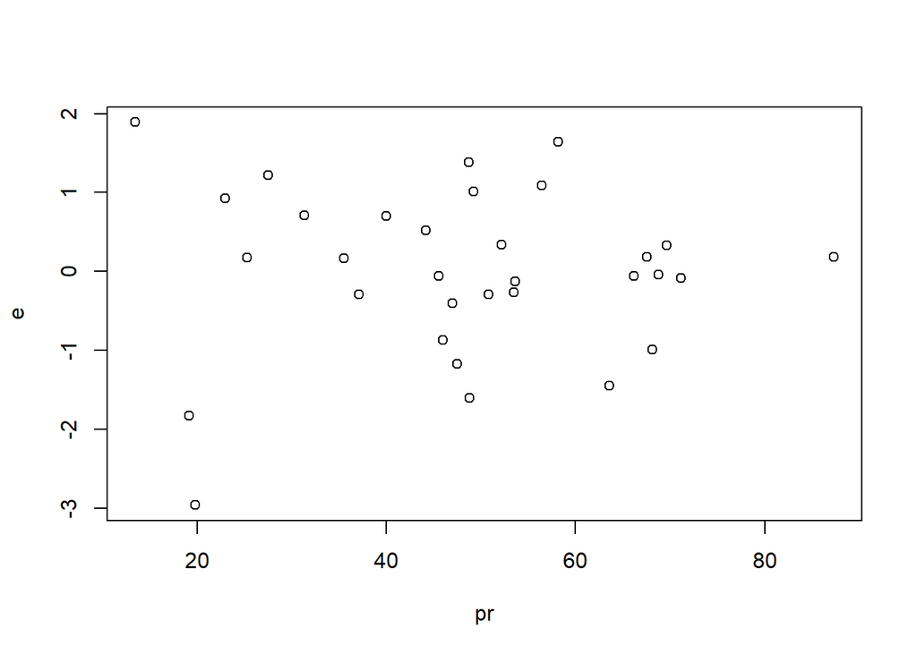

```r
plot(pr, e)
```

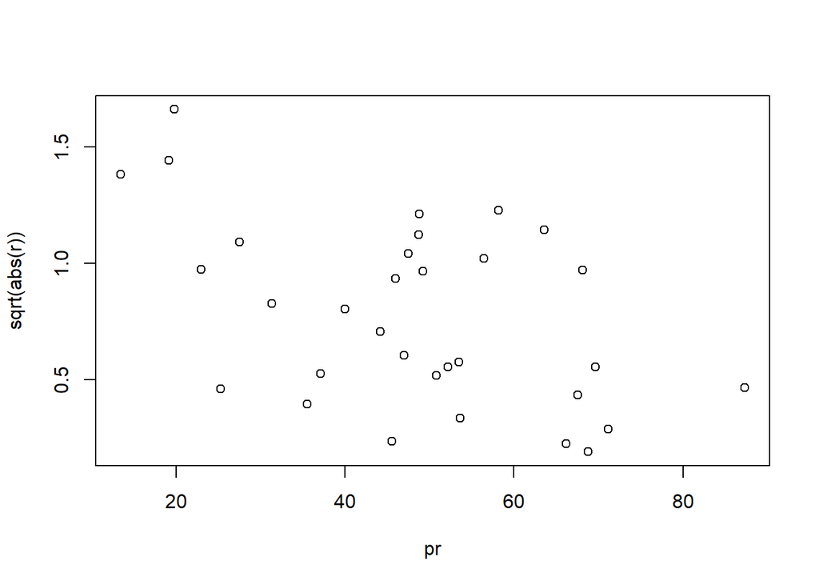

```r
plot(pr, sqrt(abs(r)))
```

Los residuales ordinarios y estandarizados no presentan un comportamiendo que puedan indicar tendencia lineal o se asemeje a alguna figura geométrica o se aleje de los supuestos de aleatoriedad o varianza constante. No existe una tendencia marcada. Encontramos una nube de puntos dispersa. Sin embargo, es de notar que existen 4 valores posiblemente atípicos. En conclusión, no se rechaza la hipótesis de normalidad de los residuales en este modelo.

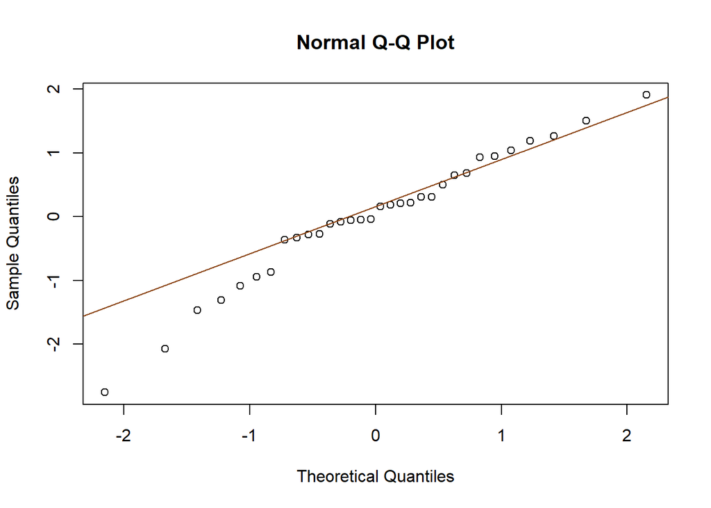

```r
qqnorm(r)
qqline(r, col="chocolate4")
```

Se evidencia una desviación de la normalidad en la cola inferior de los residuales. Se debe realizar una prueba de normalidad de los residuales para mayor certeza en este supuesto.

# Prueba de normalidad

```r
shapiro.test(r)
```

```
##
##  Shapiro-Wilk normality test
##
## data:  r
## W = 0.96683, p-value = 0.4168
```

Shapiro-Wilk normality test Indica que los residuos del modelo propuesto sí tienen una distribución normal, ya que el *p-value = 0.4168* encontrado es superior al 0.05 de significancia.

# Grafico de variables explicativas

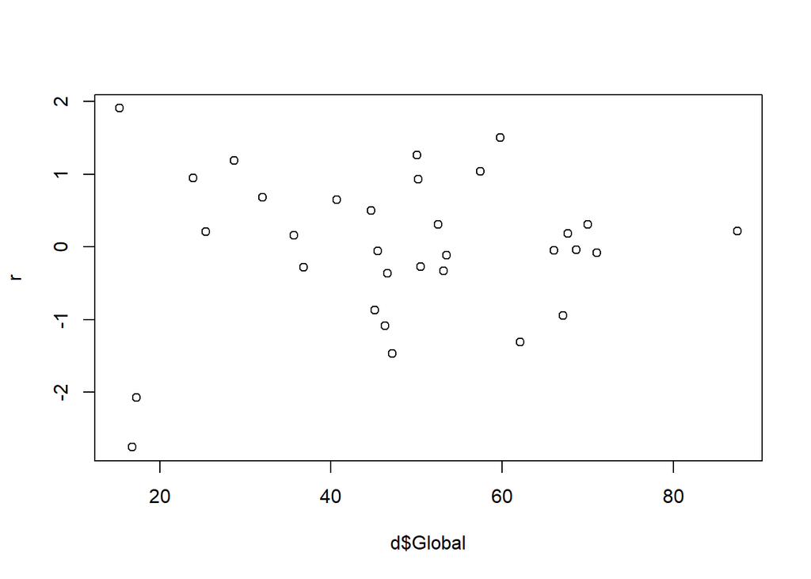

```r
plot(d$Global, r)
```

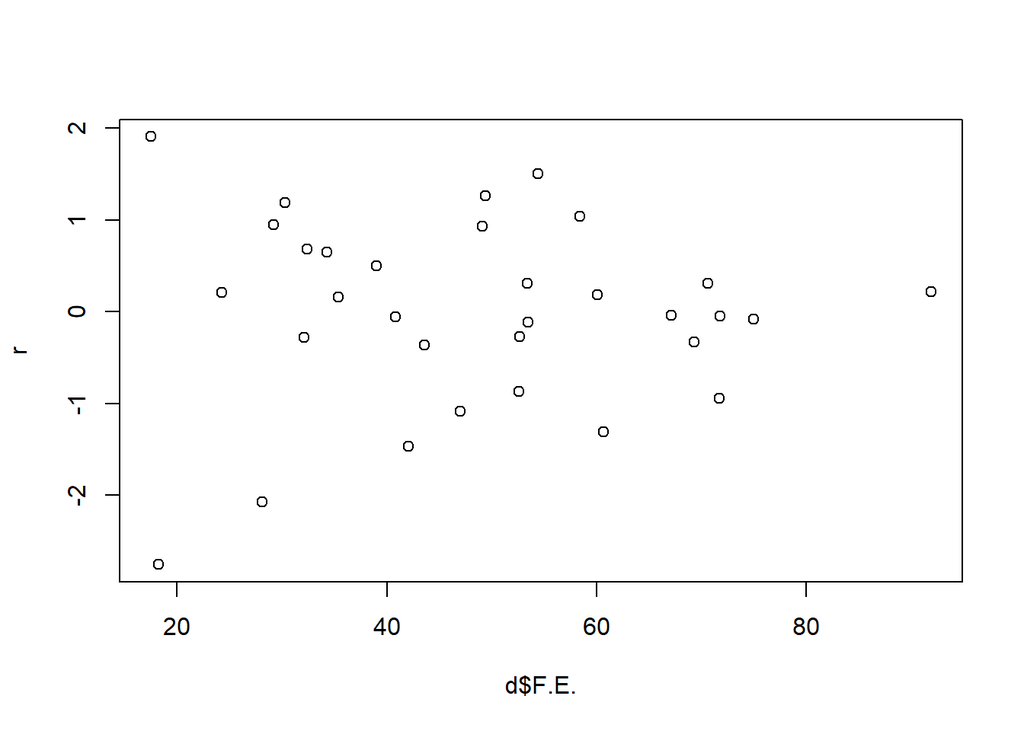

```r
plot(d$F.E., r)
```

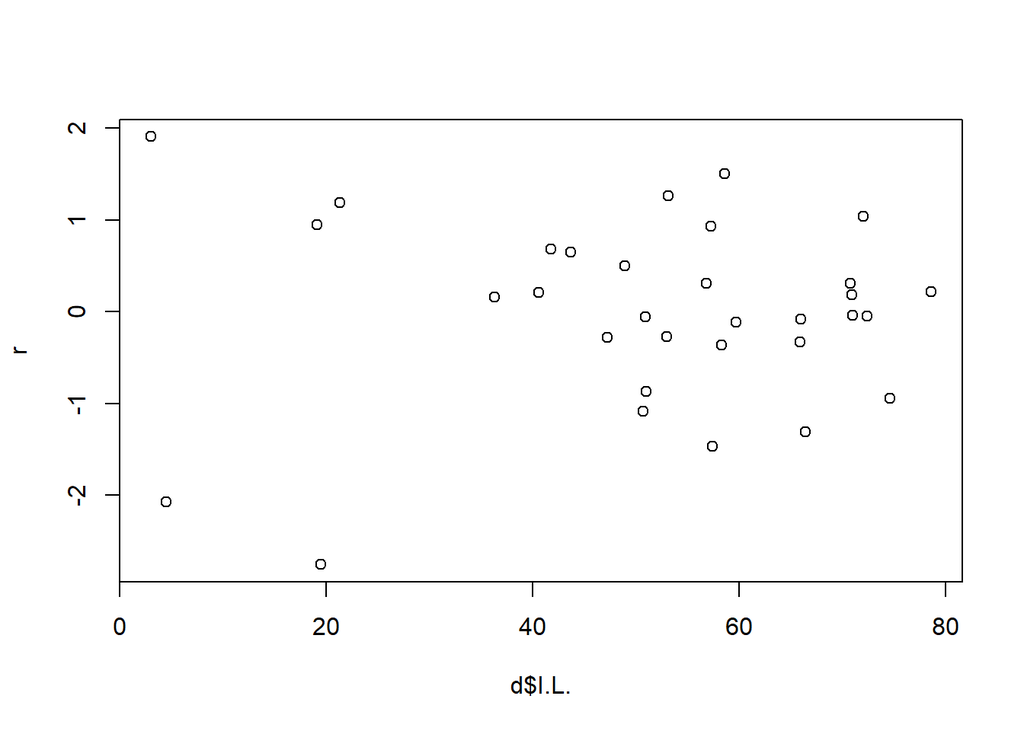

```r
plot(d$I.L., r)
```

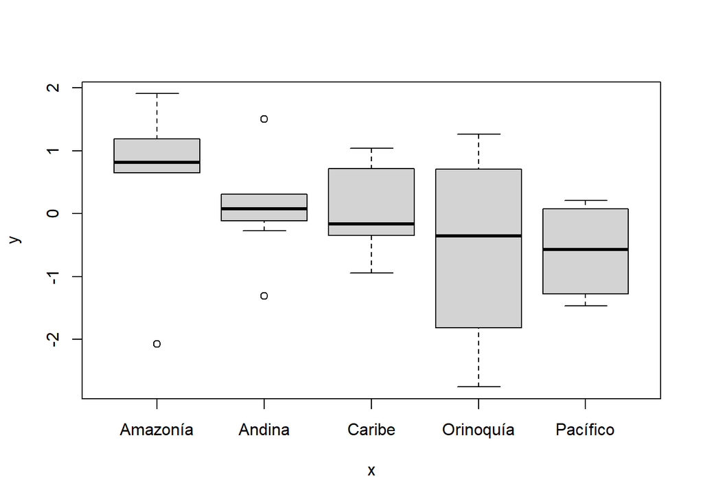

```r
plot(d$Región,r)
```

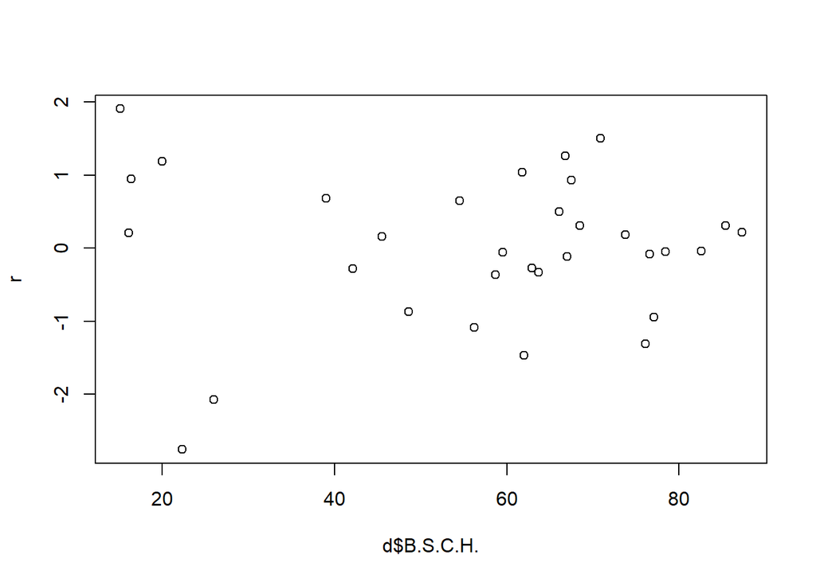

```r
plot(d$B.S.C.H., r)
```

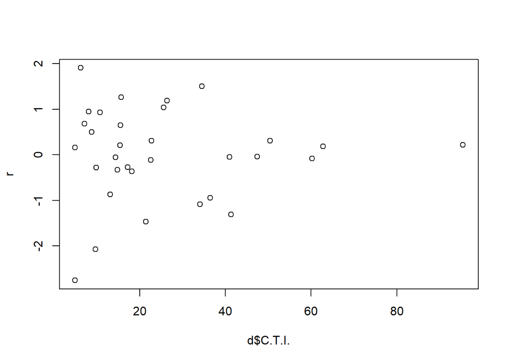

```r
plot(d$ C.T.I., r)
```

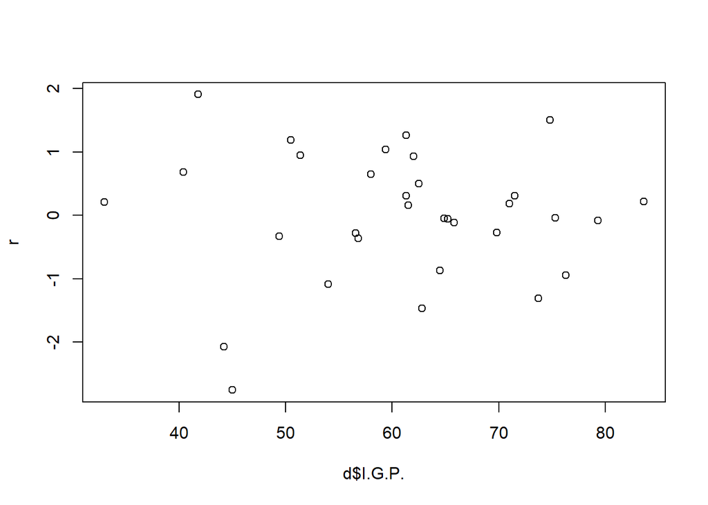

```r
plot(d$ I.G.P., r)
```

Se evidencia que existen valores atípicos en cada gráfico. En algunos se presentan 3 y en otro 4 datos atípicos. Estos pueden estar afectando el modelo

$$OBSERVACIONES~ INFLUYENTES$$

```r
p = length(mod$coefficients)-1 ; p
```

```
## [1] 5
```

```r
n = nrow(d) ; n
```

```
## [1] 32
```

# Apalancamiento

```r
apa = hii >= 2*(p+1)/n ; apa
```

```
##     1     2     3     4     5     6     7     8     9    10    11    12    13
## FALSE FALSE FALSE FALSE  TRUE FALSE FALSE FALSE FALSE FALSE FALSE FALSE  TRUE
##    14    15    16    17    18    19    20    21    22    23    24    25    26
## FALSE  TRUE FALSE FALSE FALSE FALSE FALSE FALSE FALSE FALSE FALSE FALSE  TRUE
##    27    28    29    30    31    32
## FALSE FALSE FALSE FALSE FALSE FALSE
```

```r
d[apa,]
```

```
## # A tibble: 4 x 8
##   Dpto                  Global  F.E.  I.L. B.S.C.H. C.T.I. I.G.P. Región
##   <chr>                  <dbl> <dbl> <dbl>    <dbl>  <dbl>  <dbl> <fct>
## 1 Bogotá – Cundinamarca   87.5  91.9  78.6     87.3   95.4   83.6 Andina
## 2 Chocó                   25.4  24.3  40.6     16.1   15.4   33   Pacífico
## 3 Guainía                 17.3  28.1   4.5     26      9.7   44.2 Amazonía
## 4 San Andrés              53.2  69.3  65.9     63.7   14.8   49.4 Caribe
```

# Inconsitente

```r
inc = abs(ri) >= qt(1-0.05/(2*n),n-p-2) ; inc
```

```
##     1     2     3     4     5     6     7     8     9    10    11    12    13
## FALSE FALSE FALSE FALSE FALSE FALSE FALSE FALSE FALSE FALSE FALSE FALSE FALSE
##    14    15    16    17    18    19    20    21    22    23    24    25    26
## FALSE FALSE FALSE FALSE FALSE FALSE FALSE FALSE FALSE FALSE FALSE FALSE FALSE
##    27    28    29    30    31    32
## FALSE FALSE FALSE FALSE FALSE FALSE
```

```r
d[inc,]
```

```
## # A tibble: 0 x 8
## # ... with 8 variables: Dpto <chr>, Global <dbl>, F.E. <dbl>, I.L. <dbl>,
## #   B.S.C.H. <dbl>, C.T.I. <dbl>, I.G.P. <dbl>, Región <fct>
```

No existen puntos inconstentes, todos se marcaron como **FALSE**, en caso contrario deberia aparecer **TRUE** para el posible dato inconsistente.

# Medidas de influencia

```r
inf = influence.measures(mod)
#inf
#inf$is.inf
d[apply(inf$is.inf, 1, sum)>0,]
```

```
## # A tibble: 5 x 8
##   Dpto                  Global  F.E.  I.L. B.S.C.H. C.T.I. I.G.P. Región
##   <chr>                  <dbl> <dbl> <dbl>    <dbl>  <dbl>  <dbl> <fct>
## 1 Bogotá – Cundinamarca   87.5  91.9  78.6     87.3   95.4   83.6 Andina
## 2 Chocó                   25.4  24.3  40.6     16.1   15.4   33   Pacífico
## 3 Guainía                 17.3  28.1   4.5     26      9.7   44.2 Amazonía
## 4 San Andrés              53.2  69.3  65.9     63.7   14.8   49.4 Caribe
## 5 Vichada                 16.8  18.2  19.5     22.3    4.9   45   Orinoquía
```

Existen 5 valores que infringen el critero de influencia.

```r
library(lmtest)
bptest(mod)
```

```
##
##  studentized Breusch-Pagan test
##
## data:  mod
## BP = 9.477, df = 5, p-value = 0.09148
```

Breusch-Pagan test indica que la varianza de los residuales de este modelo es constante. Ya que el *p-value = 0.09148* encontrado es superior al 0.05 de significancia. Entonces no se rechaza la *Homocedasticidad* de los residuales.

En conclusión tenemos que los residuales siguen una distribucion aporoximadamente normal, son aleatorios, independientes y presentan varianza constante.

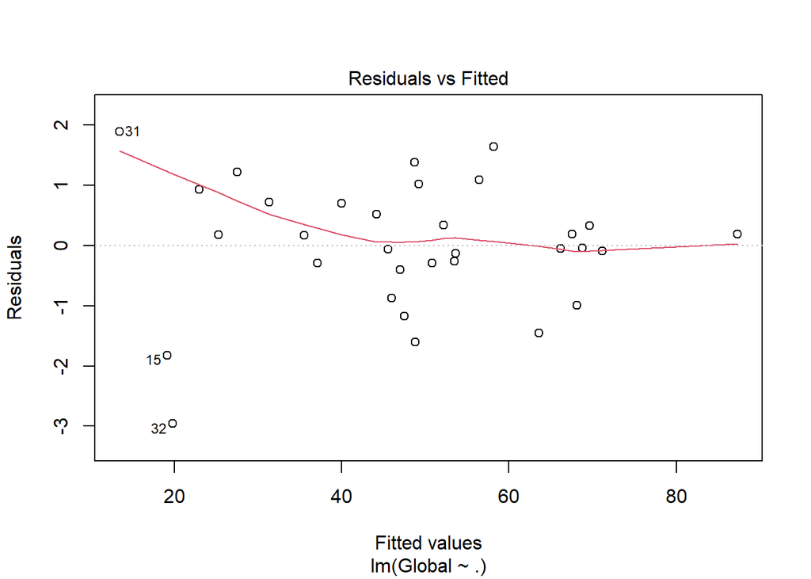

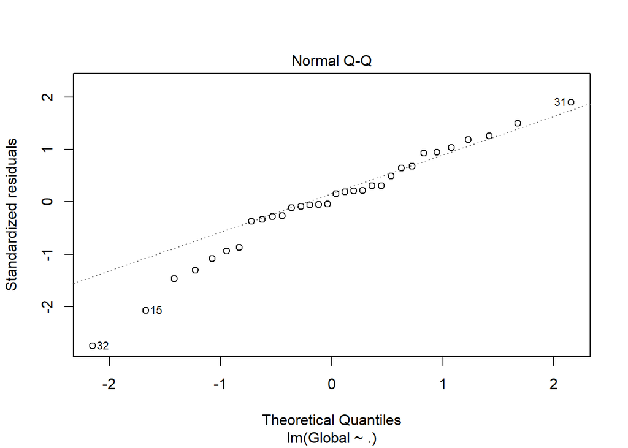

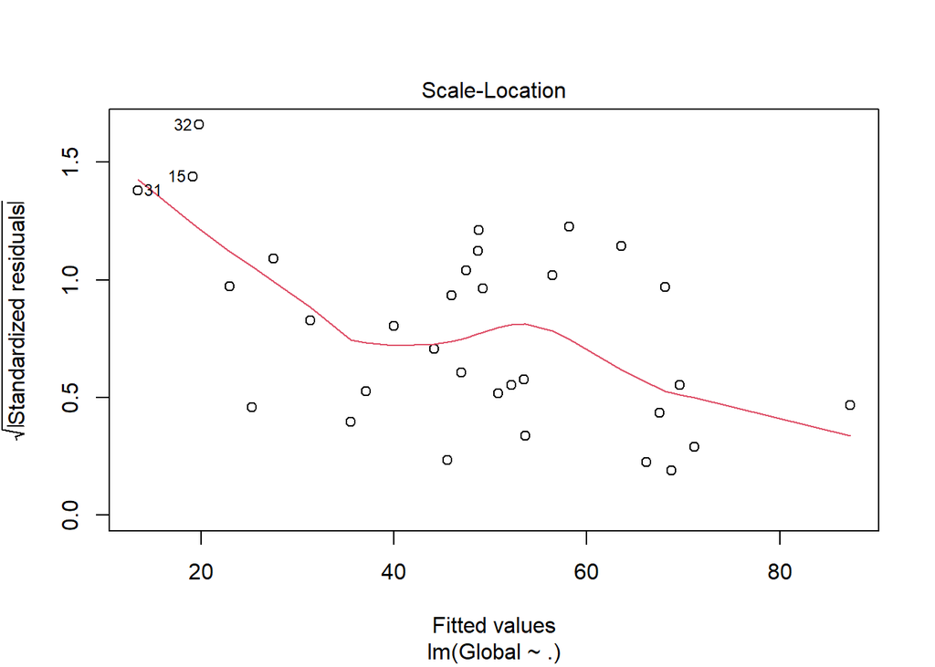

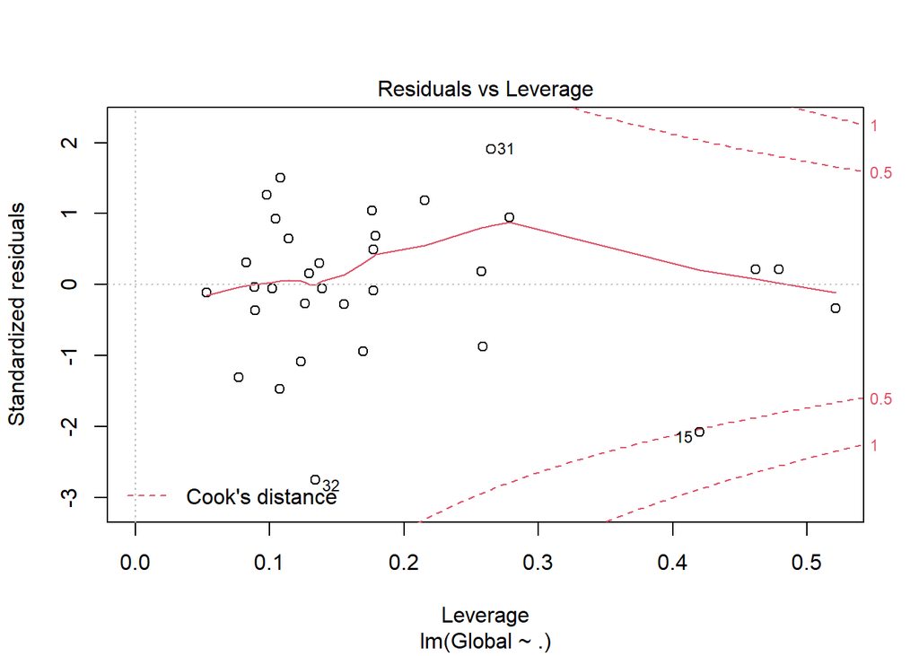

```r
plot(mod)
```

De las gráficas se desprende la presencia de posibles datos atípicos en las filas 15,31,32. Dos de estos valores tambien fueron catalogados como influyentes según los analisis anteriores.

```r
# Datos atípicos e influyentes de la base inicial.
d[c(15,31,32),]
```

```
## # A tibble: 3 x 8
##   Dpto    Global  F.E.  I.L. B.S.C.H. C.T.I. I.G.P. Región
##   <chr>    <dbl> <dbl> <dbl>    <dbl>  <dbl>  <dbl> <fct>
## 1 Guainía   17.3  28.1   4.5     26      9.7   44.2 Amazonía
## 2 Vaupés    15.3  17.5   3       15.1    6.2   41.8 Amazonía
## 3 Vichada   16.8  18.2  19.5     22.3    4.9   45   Orinoquía
```

# Datos atípicos

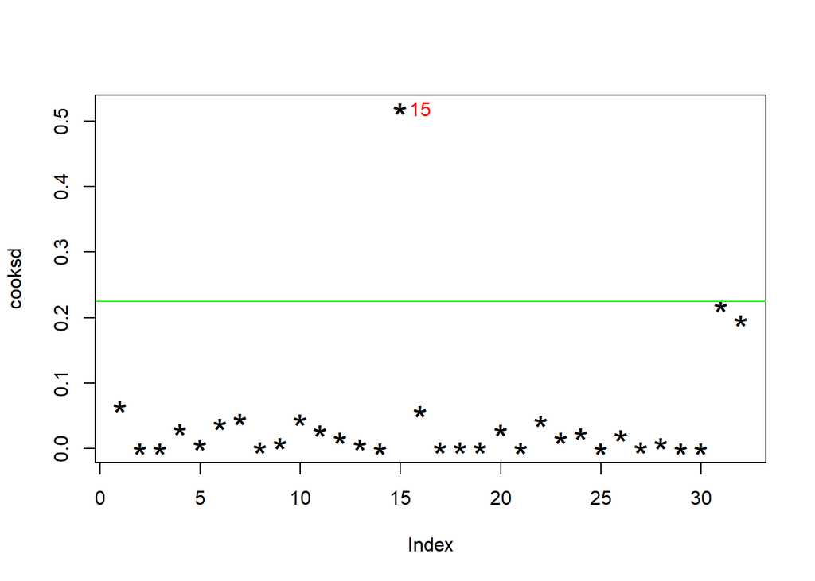

```r
cooksd<-cooks.distance(mod)

plot(cooksd, pch="*", cex=2)
abline(h = 5*mean(cooksd, na.rm=T), col="green")
 text(x=1:length(cooksd)+1, y=cooksd,
       labels=ifelse(cooksd>5*mean(cooksd, na.rm=T),
        names(cooksd),""),
        col="red")
```

El valor de la fila 15 (Guanía) es influyete en términos de la distancia de Cooks. También catalogado como valor influyente.

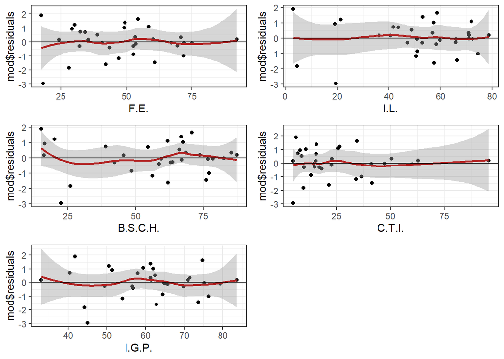

Encontramos que se cumple una linealidad para todos los predictores del modelo. Donde la mayoría de puntos estan cercanos a 0 para cada una de las variables evaluadas.

$$NUEVO~MODELO~DE~REGRESIÓN~LINEAL~MULTIMPLE$$
Se crea un nuevo modelo pero se retiran los datos **influyentes.**

```r
d2<-d[-c(5,13,15,26,31,32),-c(1,8)]
mod2 = lm(Global  ~., data =d2)
summary(mod2)
```

```
##
## Call:
## lm(formula = Global ~ ., data = d2)
##
## Residuals:
##      Min       1Q   Median       3Q      Max
## -1.64155 -0.32715 -0.04401  0.30309  1.74321
##
## Coefficients:
##             Estimate Std. Error t value Pr(>|t|)
## (Intercept) -1.16239    1.63430  -0.711 0.485144
## F.E.         0.24218    0.03614   6.702 1.60e-06 ***
## I.L.         0.22028    0.03791   5.811 1.10e-05 ***
## B.S.C.H.     0.20003    0.03065   6.526 2.32e-06 ***
## C.T.I.       0.17709    0.01784   9.928 3.57e-09 ***
## I.G.P.       0.17171    0.03710   4.629 0.000162 ***
## ---
## Signif. codes:  0 '***' 0.001 '**' 0.01 '*' 0.05 '.' 0.1 ' ' 1
##
## Residual standard error: 0.8833 on 20 degrees of freedom
## Multiple R-squared:  0.9964, Adjusted R-squared:  0.9956
## F-statistic:  1122 on 5 and 20 DF,  p-value: < 2.2e-16
```

Se evidencia que todas la variables son significativas y un Adjusted R-squared alto, cercano a 1.

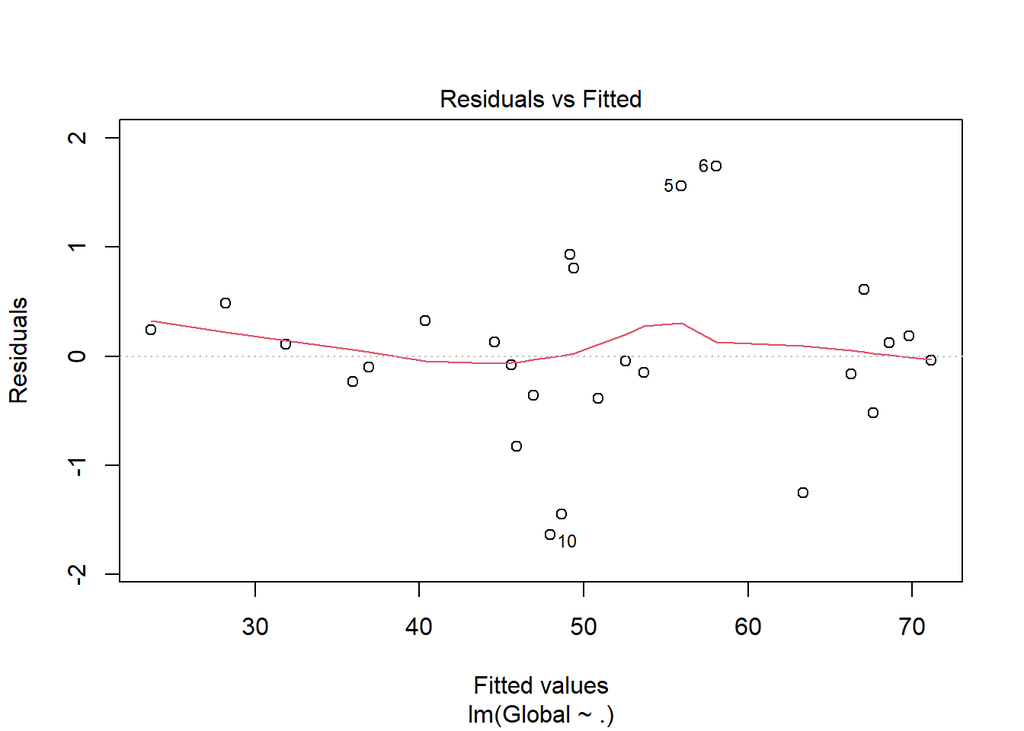

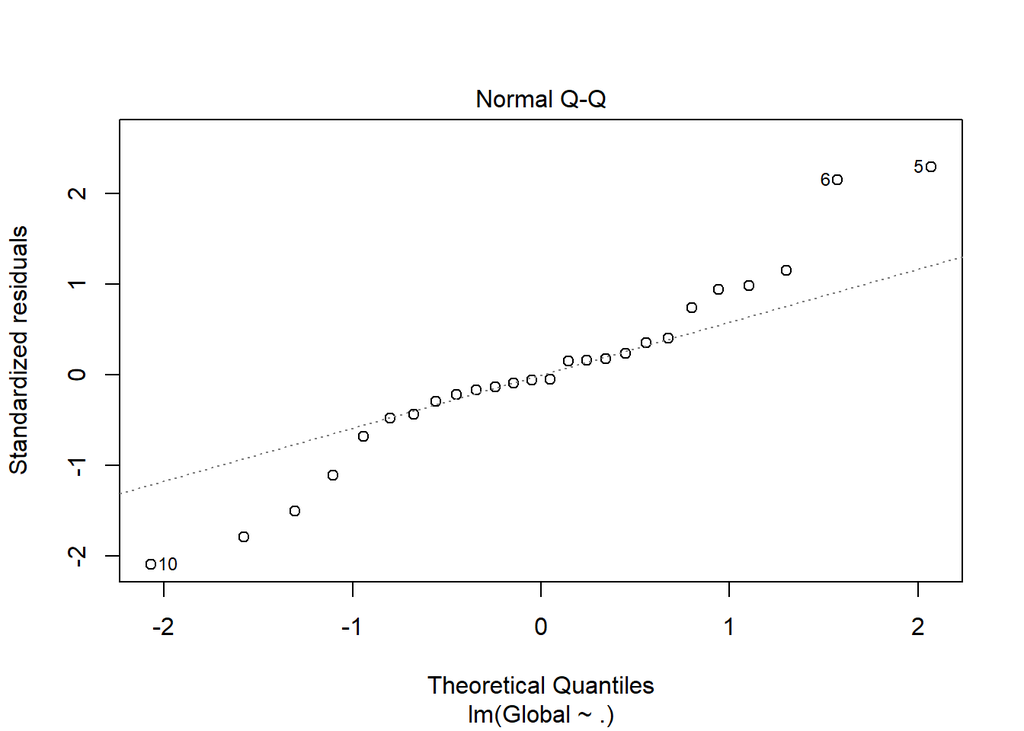

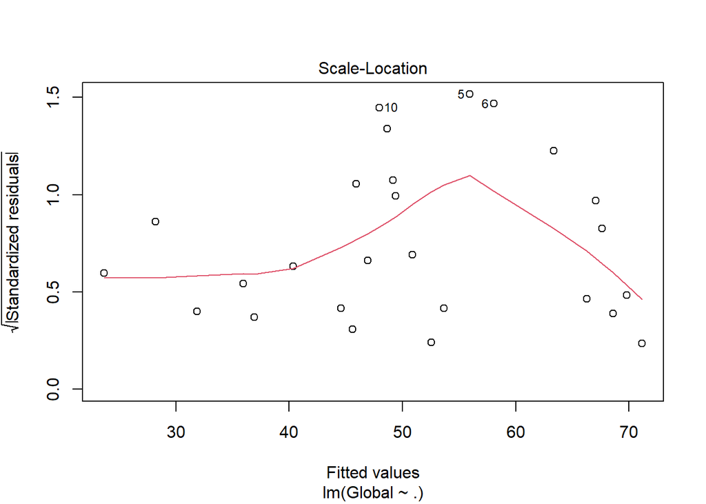

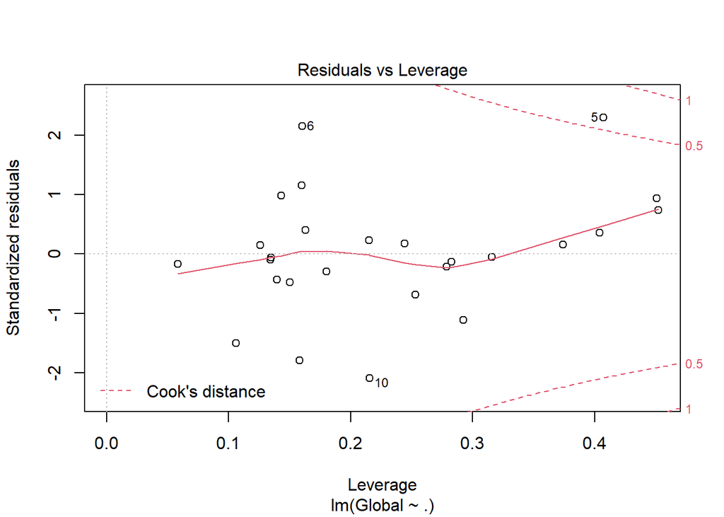

```r
plot(mod2)
```

```r
library(olsrr)
all.mod = ols_step_all_possible(mod2) ; all.mod
```

```
##    Index N                       Predictors  R-Square Adj. R-Square Mallow's Cp
## 1      1 1                             F.E. 0.9172992     0.9138534   443.46769
## 2      2 1                             I.L. 0.8742908     0.8690529   685.53384
## 3      3 1                         B.S.C.H. 0.8686821     0.8632105   717.10147
## 5      4 1                           I.G.P. 0.7099089     0.6978218  1610.73015
## 4      5 1                           C.T.I. 0.6838880     0.6707167  1757.18429
## 7      6 2                    F.E. B.S.C.H. 0.9702097     0.9676193   147.66963
## 13     7 2                  B.S.C.H. C.T.I. 0.9634837     0.9603083   185.52619
## 6      8 2                        F.E. I.L. 0.9569898     0.9532498   222.07566
## 11     9 2                      I.L. C.T.I. 0.9520835     0.9479168   249.69016
## 12    10 2                      I.L. I.G.P. 0.9428615     0.9378930   301.59441
## 9     11 2                      F.E. I.G.P. 0.9343075     0.9285951   349.73963
## 8     12 2                      F.E. C.T.I. 0.9288123     0.9226220   380.66851
## 10    13 2                    I.L. B.S.C.H. 0.9071217     0.8990454   502.75013
## 14    14 2                  B.S.C.H. I.G.P. 0.9003102     0.8916415   541.08764
```

[output cut: 17 more lines]

Para el **mod2** se usaron 5 varibles. Se debe escoger el numero de predictores cercanos a este valor de acuerdo al indice Mallows.

Mallows indica que el mejor modelo debe contener las variales F.E. I.L. B.S.C.H. C.T.I. I.G.P., ya que presnta un indice de Mallow’s Cp= 6. Muy cercano al valor de las variables que contiene el modelo evaluado. Ademas, usando estas variables Mallows indica que se puede explicar el comportamientos de la variable dependiente *Indice global*

```r
sub.mod = ols_step_best_subset(mod) ; sub.mod
```

```
##             Best Subsets Regression
## -----------------------------------------------
## Model Index    Predictors
## -----------------------------------------------
##      1         F.E.
##      2         B.S.C.H. C.T.I.
##      3         I.L. B.S.C.H. C.T.I.
##      4         F.E. I.L. C.T.I. I.G.P.
##      5         F.E. I.L. B.S.C.H. C.T.I. I.G.P.
## -----------------------------------------------
##
##                                                      Subsets Regression Summary
## ------------------------------------------------------------------------------------------------------------------------------------
##                        Adj.        Pred
## Model    R-Square    R-Square    R-Square      C(p)        AIC         SBIC        SBC         MSEP        FPE       HSP       APC
## ------------------------------------------------------------------------------------------------------------------------------------
##   1        0.9214      0.9188      0.9108    542.2955    198.1766    101.8071    202.5738    810.8237    26.9183    0.8736    0.0890
##   2        0.9673      0.9651      0.9607    211.0322    172.0819     74.5834    177.9449    349.0389    11.9142    0.3890    0.0394
##   3        0.9858      0.9842      0.9807     79.4296    147.5442     50.2533    154.8728    157.9449     5.5383    0.1823    0.0183
##   4        0.9927      0.9917      0.9902     30.6893    127.9608     32.9137    136.7552     83.5552     3.0071    0.1000    0.0099
##   5        0.9964      0.9957      0.9944      6.0000    107.3587     19.2094    117.6189     42.8803     1.5826    0.0533    0.0052
## ------------------------------------------------------------------------------------------------------------------------------------
## AIC: Akaike Information Criteria
##  SBIC: Sawa's Bayesian Information Criteria
##  SBC: Schwarz Bayesian Criteria
##  MSEP: Estimated error of prediction, assuming multivariate normality
##  FPE: Final Prediction Error
##  HSP: Hocking's Sp
##  APC: Amemiya Prediction Criteria
```

Indica que el menor ACI lo presenta el modelo que contiene las variables F.E. I.L. B.S.C.H. C.T.I. I.G.P. Este modelo corresponde al mismo que presenta el mejor índice de Mallows.

```r
summary(step(mod2, direction = "both"))
```

```
## Start:  AIC=-1.27
## Global ~ F.E. + I.L. + B.S.C.H. + C.T.I. + I.G.P.
##
##            Df Sum of Sq    RSS    AIC
## <none>                  15.604 -1.274
## - I.G.P.    1    16.716 32.320 15.657
## - I.L.      1    26.347 41.951 22.439
## - B.S.C.H.  1    33.226 48.831 26.387
## - F.E.      1    35.042 50.646 27.336
## - C.T.I.    1    76.898 92.502 42.998
```

```
##
## Call:
## lm(formula = Global ~ F.E. + I.L. + B.S.C.H. + C.T.I. + I.G.P.,
##     data = d2)
##
## Residuals:
##      Min       1Q   Median       3Q      Max
## -1.64155 -0.32715 -0.04401  0.30309  1.74321
##
## Coefficients:
##             Estimate Std. Error t value Pr(>|t|)
## (Intercept) -1.16239    1.63430  -0.711 0.485144
## F.E.         0.24218    0.03614   6.702 1.60e-06 ***
## I.L.         0.22028    0.03791   5.811 1.10e-05 ***
## B.S.C.H.     0.20003    0.03065   6.526 2.32e-06 ***
## C.T.I.       0.17709    0.01784   9.928 3.57e-09 ***
## I.G.P.       0.17171    0.03710   4.629 0.000162 ***
## ---
## Signif. codes:  0 '***' 0.001 '**' 0.01 '*' 0.05 '.' 0.1 ' ' 1
##
## Residual standard error: 0.8833 on 20 degrees of freedom
## Multiple R-squared:  0.9964, Adjusted R-squared:  0.9956
## F-statistic:  1122 on 5 and 20 DF,  p-value: < 2.2e-16
```

Suguiere que el mejor modelo es aquel que contiene las siguientes variables F.E. + I.L. + B.S.C.H. + C.T.I. + I.G.P

```r
cor(d2[,-1])
```

```
##               F.E.      I.L.  B.S.C.H.    C.T.I.    I.G.P.
## F.E.     1.0000000 0.8759182 0.8445253 0.7955749 0.7975855
## I.L.     0.8759182 1.0000000 0.9215490 0.6604550 0.7015206
## B.S.C.H. 0.8445253 0.9215490 1.0000000 0.6310016 0.7860526
## C.T.I.   0.7955749 0.6604550 0.6310016 1.0000000 0.6606388
## I.G.P.   0.7975855 0.7015206 0.7860526 0.6606388 1.0000000
```

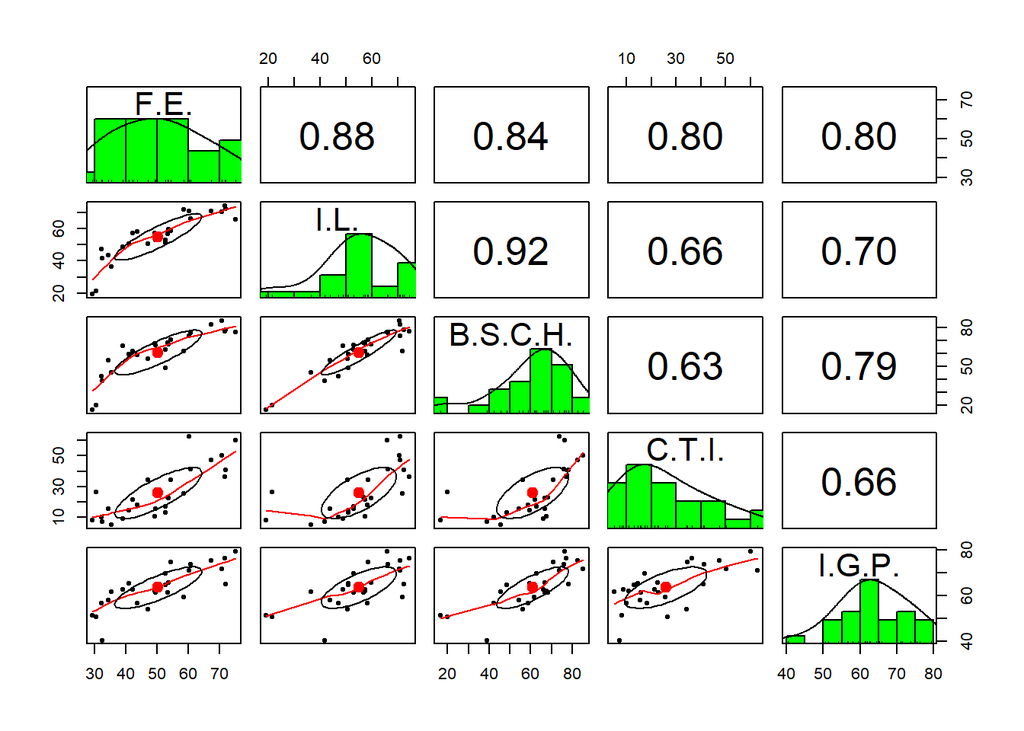

```r
library(psych)

pairs.panels(d2[,-1],
             method="pearson",
             hist.col ="green")
```

Sin Embargo, al evaluar las correlaciones, se evidencia aque existe multicolinealidad entre todas las variable predictoras.

Entonces para seleccionar el mejor modelo de regresión lineal para el **Indice Global** se va a construir variable por variable hasta encontrar un modelo que no presente multicolinealidad.

Los daots evaluados presenta multicolineadlidad. Entonces se debe proponer un modelo de regresión simple.

```r
mod3<-lm(formula = Global ~ F.E., data = d2)
summary(mod3)
```

```
##
## Call:
## lm(formula = Global ~ F.E., data = d2)
##
## Residuals:
##     Min      1Q  Median      3Q     Max
## -7.8055 -2.4220 -0.0585  2.5848  7.9666
##
## Coefficients:
##             Estimate Std. Error t value Pr(>|t|)
## (Intercept)   5.0190     2.9062   1.727    0.097 .
## F.E.          0.9104     0.0558  16.316 1.72e-14 ***
## ---
## Signif. codes:  0 '***' 0.001 '**' 0.01 '*' 0.05 '.' 0.1 ' ' 1
##
## Residual standard error: 3.89 on 24 degrees of freedom
## Multiple R-squared:  0.9173, Adjusted R-squared:  0.9139
## F-statistic: 266.2 on 1 and 24 DF,  p-value: 1.717e-14
```

Este modelo presenta un Adjusted R-squared: 0.9139

```r
mod4<-lm(formula = Global ~ I.L., data = d2)
summary(mod4)
```

```
##
## Call:
## lm(formula = Global ~ I.L., data = d2)
##
## Residuals:
##     Min      1Q  Median      3Q     Max
## -7.7975 -2.1666 -0.1247  2.9000 10.9195
##
## Coefficients:
##             Estimate Std. Error t value Pr(>|t|)
## (Intercept)  3.89328    3.74849   1.039    0.309
## I.L.         0.85284    0.06601  12.920 2.67e-12 ***
## ---
## Signif. codes:  0 '***' 0.001 '**' 0.01 '*' 0.05 '.' 0.1 ' ' 1
##
## Residual standard error: 4.796 on 24 degrees of freedom
## Multiple R-squared:  0.8743, Adjusted R-squared:  0.8691
## F-statistic: 166.9 on 1 and 24 DF,  p-value: 2.67e-12
```

Este modelo presenta un Adjusted R-squared: 0.8691

```r
mod5<-lm(formula = Global ~ B.S.C.H., data = d2)
summary(mod5)
```

```
##
## Call:
## lm(formula = Global ~ B.S.C.H., data = d2)
##
## Residuals:
##     Min      1Q  Median      3Q     Max
## -9.7567 -3.9903 -0.8461  3.0443  9.1722
##
## Coefficients:
##             Estimate Std. Error t value Pr(>|t|)
## (Intercept)  7.42386    3.57217   2.078   0.0485 *
## B.S.C.H.     0.71154    0.05647  12.600 4.52e-12 ***
## ---
## Signif. codes:  0 '***' 0.001 '**' 0.01 '*' 0.05 '.' 0.1 ' ' 1
##
## Residual standard error: 4.902 on 24 degrees of freedom
## Multiple R-squared:  0.8687, Adjusted R-squared:  0.8632
## F-statistic: 158.8 on 1 and 24 DF,  p-value: 4.521e-12
```

Este modelo presenta un Adjusted R-squared: 0.8632

```r
mod6<-lm(formula = Global ~ C.T.I., data = d2)
summary(mod6)
```

```
##
## Call:
## lm(formula = Global ~ C.T.I., data = d2)
##
## Residuals:
##     Min      1Q  Median      3Q     Max
## -22.474  -3.056   2.475   5.065   9.388
##
## Coefficients:
##             Estimate Std. Error t value Pr(>|t|)
## (Intercept)  33.7499     2.7939  12.080 1.09e-11 ***
## C.T.I.        0.6600     0.0916   7.206 1.91e-07 ***
## ---
## Signif. codes:  0 '***' 0.001 '**' 0.01 '*' 0.05 '.' 0.1 ' ' 1
##
## Residual standard error: 7.605 on 24 degrees of freedom
## Multiple R-squared:  0.6839, Adjusted R-squared:  0.6707
## F-statistic: 51.92 on 1 and 24 DF,  p-value: 1.908e-07
```

Este modelo presenta un Adjusted R-squared: 0.6707

```r
mod7<-lm(formula = Global ~ I.G.P., data = d2)
summary(mod7)
```

```
##
## Call:
## lm(formula = Global ~ I.G.P., data = d2)
##
## Residuals:
##      Min       1Q   Median       3Q      Max
## -12.6268  -5.3453   0.2016   4.3315  13.5823
##
## Coefficients:
##             Estimate Std. Error t value Pr(>|t|)
## (Intercept) -27.4803    10.3104  -2.665   0.0135 *
## I.G.P.        1.2326     0.1608   7.664 6.69e-08 ***
## ---
## Signif. codes:  0 '***' 0.001 '**' 0.01 '*' 0.05 '.' 0.1 ' ' 1
##
## Residual standard error: 7.286 on 24 degrees of freedom
## Multiple R-squared:  0.7099, Adjusted R-squared:  0.6978
## F-statistic: 58.73 on 1 and 24 DF,  p-value: 6.692e-08
```

Ahora, de todos los modelos evaluados, escogemos el que presentó mayor Adjusted R-squared

```r
summary(mod3)
```

```
##
## Call:
## lm(formula = Global ~ F.E., data = d2)
##
## Residuals:
##     Min      1Q  Median      3Q     Max
## -7.8055 -2.4220 -0.0585  2.5848  7.9666
##
## Coefficients:
##             Estimate Std. Error t value Pr(>|t|)
## (Intercept)   5.0190     2.9062   1.727    0.097 .
## F.E.          0.9104     0.0558  16.316 1.72e-14 ***
## ---
## Signif. codes:  0 '***' 0.001 '**' 0.01 '*' 0.05 '.' 0.1 ' ' 1
##
## Residual standard error: 3.89 on 24 degrees of freedom
## Multiple R-squared:  0.9173, Adjusted R-squared:  0.9139
## F-statistic: 266.2 on 1 and 24 DF,  p-value: 1.717e-14
```

Evaluamos el criterio de AIC

```r
AIC(mod3, mod4, mod5, mod6, mod7)
```

```
##      df      AIC
## mod3  3 148.3407
## mod4  3 159.2280
## mod5  3 160.3629
## mod6  3 183.2032
## mod7  3 180.9698
```

El modelo (mod3) presenta el menor valor de AIC.

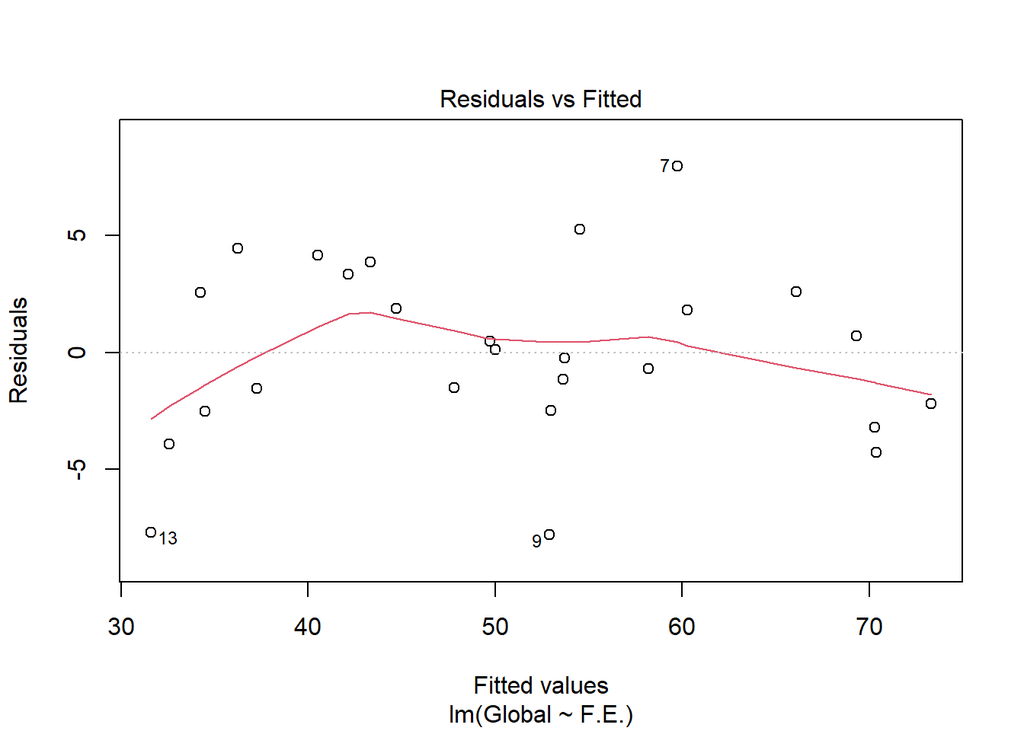

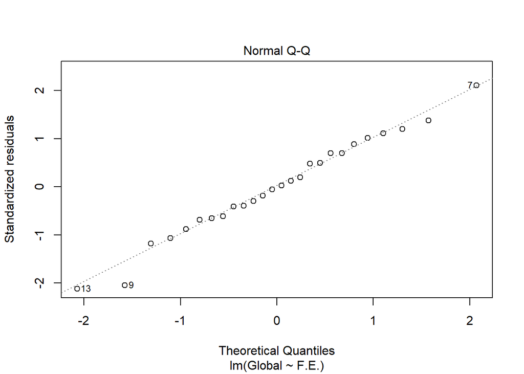

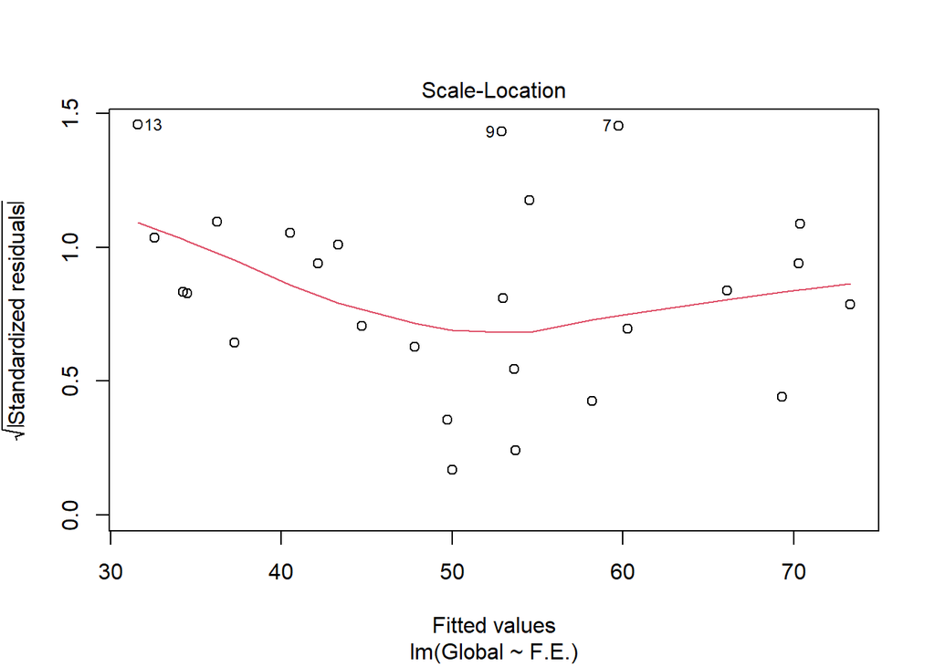

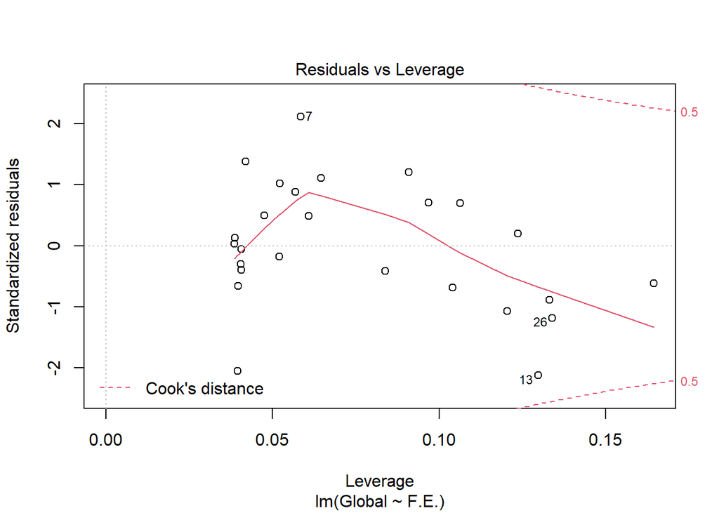

```r
plot(mod3)
```

Finalmente, despues de realizar el analisis completo para encontrar el modelo de regresión linieal de estos datos, se plantea que para predecir el indice de Competitividad Global debe estar en función de la Fortaleza de la Economia.